# Writing a great story for data science projects - Fall 2025

This is a Report Template Quarto

Author

Namita Mishra (Advisor: Dr. Cohen)

Published

September 5, 2025

Slides: slides.html ( Go to `slides.qmd` to edit)

**Important**

**Remember:** Your goal is to make your audience understand and care about your findings. By crafting a compelling story, you can effectively communicate the value of your data science project.

Carefully read this template since it has instructions and tips to writing!

Nice report!

## Introduction

What is the goal of the paper? The authors aimed to develop a bayesian hierarchical model for multivariate longitudinal data to predict the health status, trajectory, and likely intervention effects for each member of a clinical population in the PCORI mission, and to address questions about health care from patients and clinicians.

Why is it important? Medical data includes DNA sequences, functional images of the brain, patient-reported outcomes and the electronic health record capturing patient’s sequence of health measurements, diagnoses, and treatments. Full use of the electronic health record (EHR) of patients could improve diagnostic accuracy and prediction of treatment effects, since the standard approaches for analyzing clinical data are not adequate for this purpose. The bayesian hierarchical model combines diverse sources of prior knowledge and patient data with evidence, to predict the patient’s health status, trajectory, and/or likely benefits of interventions. Visualizations of characteristics of posterior distributions can be immediately understood by clinicians and patients as relevant to their decision.

How is it solved? – methods They applied Bayesian hierarchical regression for multivariate longitudinal patient data using open-source R-packages was developed 2 levels—time within person and persons within a population The model comprised: the effects of exogenous (eg, age, clinical history) and endogenous (eg, current treatment) variables on the individual’s health status; multivariate health measurements for health status; the effects of health measurements at one time on subsequent interventions. The model produces an estimate of the posterior distribution of the trend in health status for each value of the predictor variables and produces an estimate of the marginal distribution of the regression coefficients; each coefficient measures how the outcome, health status, is associated with its predictor variable (R, X). In a larger sample, the likelihood dominates the prior distribution for key parameters such as regression coefficients. The bayesian hierarchical model is adaptable because (1) it is a likelihood-based approach.(2) use of priors (prior laboratory and clinical trials data) provide a reasonable range for the assay sensitivities that, once imposed through the prior assumptions, make the model identifiable (3) Markov chain Monte Carlo (MCMC) estimate the posterior distributions to avoid missing data and complex outcome measurements.

Why is it important? Medical diagnosis is crucial for treatment and management decisions and uses conventional methods for diagnosis using clinical criteria and fixed numerical thresholds limits capturing other information about the intricate relations between diagnostic tests and the varying prevalence of diseases. The probability distributions associated with quantitative diagnostic test outcomes often demonstrate some overlap between the diseased and nondiseased groups. Dichotomous method fail to capture the complexity and heterogeneity of disease presentations across diverse populations. The applicability of the normal distribution in conventional method is critiqued, especially when dealing with clinical measurands that exhibit skewness, bimodality, or multimodality

How is it solved? – methods To authors explored and developed specialized computational tool employing Bayesian inference (Bayesian diagnostic approach is) to calculate the posterior probability of disease diagnosis in theWolfram Language. Bayesian paradigm, calculates and integrate prior probabilities of disease with distributions of diagnostic measurands in both diseased and nondiseased populations, the approach enables the evaluation of the information conveyed via diagnostic measurements and the combination of data from multiple diagnostic tests, to improve diagnostic accuracy and precision while introducing flexibility, adaptability, and versatility into the diagnostic process. The foundational data is crucial in establishing the essential context against which new diagnostic measurements can be compared and the absence of such normative data could potentially compromise the reliability and validity of Bayesian diagnostic methods.

Results/limitations, if any. Nonparametric Bayesian models produce a better fit to data distributions, considering limited existing literature and emphasizes the robustness in capturing complex data distributions. The nonparametric Bayesian probabilities for disease exhibited multimodal patterns, in contrast to the bimodal, double sigmoidal curves generated by parametric models.

In Bayesian inference, unknown parameters (random variables) have values that are varied while the (observed) data have values that are fixed, and the likelihood is a function of θ for the fixed data y. Therefore, the likelihood function summarizes a statistical model that stochastically generates all of the data, a range of possible values for θ and the observed data y.With having the prior, the likelihood, and the data, we obtain posterior distribution we model to the data to estimate the unknown parameters of the model. The model captures the primary factors that we wish to improve our understanding of. Monte Carlo integration technique provide integrals using computer simulations of sampled values from a given distribution.The author mentioned packages BRMS and Blavaan in R for simplifying the use of the probabilistic programming language Stan.

Variable selection after checking correlations among the variables can be easily incorporated into the analysis (ex- gene-to-gene interaction) to aid the identification of predictive genes in biomedical research. (genome-wide association studies). Spatial and temporal variability can be factored into Bayesian general linear models. A posterior distribution for a particular model can be used to simulate new data conditional on this distribution to assess and provides valid predictions to be used for extrapolating to future events.

Results/limitations, if any. Bayesian approaches resulted in analyzing large-scale cancer genomic data sets to identify novel molecular changes that lead to cancer initiation and progression. It helps to identify the interactions between mutated genes and capture mutational signatures that highlight key genetic interactions with the potential to allow for genomic-based patient stratification in both clinical trials and the personalized use of therapeutics and assists in answering questions about evolutionary processes in cancer.

Why is it important? The measurement errors are assumed to be additive, independent and identically distributed according to a Gaussian distribution with mean zero and variance σ2, which is usually unknown. Regression use in metrology is often applied to calibrate instruments, evaluate inter-laboratory comparisons or determine fundamental constants, but a regression model cannot be uniquely formulated as a measurement function, and the Guide to the Expression of Uncertainty in Measurement (GUM) and its supplements are not applicable directly. Bayesian inference has the advantage of accounting for additional a priori information, which typically robustifies analyses.

How is it solved? – methods These three steps (prior elicitation, posterior calculation, and robustness to prior uncertainty and model adequacy) and model assumptions are critical to Bayesian inference. In Bayesian inference, all unknowns—observables (data) as well as unobservables (parameters and auxiliary variables) considered to be random are assigned probability distributions to summarize the available information, and it updates prior knowledge about the unobservables with information about them contained in the data.The prior distribution and likelihood function are parts of a Bayesian analysis and it can be provided by simple graphical displays, by sensitivity analyses or model checking. For Normal linear regression problems (1), a convenient family for a prior distribution for θ and σ2 is the Normal inverse Gamma (NIG) distribution to a posterior from the same family of (NIG) distributions or (2) alternative families of prior distributions, hierarchical priors which assign an additional layer of distributions to uncertain prior parameters or non-para- metric priors may be considered. Graphical display options of prior and posterior distributions enhance the elicitation and interpretation process, respectively. • The NIG prior - if the variance σ2 of observations is known is a conjugate prior distribution • Vague or non-informative prior distributions can be derived from the NIG prior Bayesian inference is influenced by uncertainty in the transformation of prior knowledge to prior distributions, in the assumptions of the statistical model, and mistakes in data acquisition all influence the inference.

Why is it important? Due to the frequent combination of multiple testing with relatively low statistical power, is problematic in the framework of null hypothesis significance testing. Linear regression analyses performed do not account for the published results their summary statistics) from similar previous studies. The results from previous studies are source of relevant and readily available information and ignoring this information affects both the stability and the precision of the parameter estimates report low than they could have been, and the conclusions that can be drawn are less certain and more likely to be affected by sampling variation. Multiple linear regression, includes separate significance tests for all regression coefficients. Combined with rather modest sample sizes, this makes it likely for different studies to find different sets of statistically significant predictors and to address the use of larger samples, is not realistic.

How is it solved? – methods Bayesian linear regression accommodates prior knowledge, overcoming the absence of these formal studies from the literature. Bayesian linear regression handle the issues of increasing the sample size and to augment the data of a new study with previous results (regression coefficients and standard errors) from similar studies was an alternative. It solved the issue of univariate case issue and also on combining evidence restricted to specific predictors from different linear regression analysis (as in meta-analysis). It was a better method to resolve the issue of simultaneously combining multiple regression parameters per study, separately that ignored the relation between the regression coefficients. To construct informative priors using historical data from the previous studies (using the data) was not be possible in practice, Bayesian linear regression developed a model and included reported summary statistics from previous studies and provided a more acceptable solution when data from previous studies are not (realistically) obtainable.Categorized the model into - 1. Exchangable- when the current data and previous studies all have the same set of predictors. 2. Unexchangable – when the predictors were different Bayesian linear regression – to yield the posterior density of the model parameters, which reflects the updated knowledge about the model parameters after having observed the data, steps mentioned are- • To calculate the probability density function for the data given the unknown model parameters; taken as a function of those model parameters, this is referred to as the likelihood function. • The second part is the prior density function of the model parameters, which quantifies what is assumed to be known about the model parameters prior to observing the data. Study applied Standard multiple linear regression model, with the integration of the prior the to obtain joint posterior density using Gibbs sampler, an Ordinary Least Squares linear regression was then applied to each of these samples to obtain the estimated regression coefficients B and the corresponding standard errors S. And a hierarchical version of the replication model was developed for situations where studies are not exchangeable.

Results/limitations, if any. • Incorporating the results of previous studies in a linear regression on new data does yield a significant better parameter estimate with an adequate approximation of using the actual data of those previous studies. • About how much would be gained in comparison to using just the new data, and how large would the difference be with the ideal situations in which data from previous studies were available- it resulted in encouraging performance. • Performance of the two versions (exchangeable and unexchangeable) of the replication model were consistently superior to using current data alone. • It can thus be concluded that the model developed in this article offers the possibility of obtaining significantly better parameter estimates in a linear regression setting without needing to expend a prohibitive amount of time and energy trying to obtain data from the previous studies. • Hierarchical version (unexchangeable) of the model offers the advantage of being able to address questions about differences between studies and thus allows for explicit testing of the exchangeability assumption.

## Methods

PROBLEMS AND HEALTHCARE DATA

1. Conventional regression is not efficient in using longitudinal, hierarchical, and multivariate data to analyze time-varying outcomes, correlations within patients, and dealing missing data in predicting individual patient health timelines and treatments over time
2. Conventional diagnosis based on fixed cutoffs and rigid thresholds fails to capture and integrate the uncertainty and complex distributions of complex diagnostic tests.
3. In Cancer genomics / multi-omics study on high-dimensional, sparse, and multimodal data, classical regression is prone to overfitting. Without sensitivity analysis, the priors are not captured and may strongly influence results or may be biased. Solutions In healthcare, Bayesian Regression Bayesian regression provides flexibility, uncertainty quantification, and the ability to incorporate prior knowledge, making it superior to conventional regression in complex biomedical contexts.

METHOD - 1. Clone Prevalence Modeling • PyClone-VI or PhyloWGS, the variant allele frequency (VAF) of each mutation is modeled as a function of: o latent clonal prevalence (how many cells carry the mutation), o tumor purity, o copy number state, o sequencing error. VAFij∼Binomial(nij, θij)) : where θij is modeled as a regression-like function of clone prevalence + copy number.

These models regress observed sequencing reads (data level) on latent clone prevalences (parameter level). They add a hierarchical structure: o Clone-level latent variables shared across mutations. o Patient-level latent variables shared across clones. • Priors are specified for clone prevalence distributions and tree structures. • Posterior inference is made using Bayesian methods (MCMC in PhyloWGS, variational inference in PyClone-VI).

2. Bayesian Regression – run a logistic regression in a Bayesian framework: • P(Disease∣Tests)∝P(Tests∣Disease)⋅P(Disease) • Priors encode expected prevalence; likelihood comes from test results. • Compared parametric vs. nonparametric Bayesian regression models to capture complex distributions.
3. Bayesian regression models are flexible tools and ties predictors (e.g., genetic variants, omics features) to outcomes (phenotype, clone prevalence). phenotype ~ genotype + covariates, with priors (genetic association studies) Regression links different data modalities (For multi-omics integration) Bayesian regression links observed variant frequencies to latent clone prevalences (hierarchical regression structure).

*The common non-parametric regression model is* $Y_i = m(X_i) + \varepsilon_i$*, where* $Y_i$ *can be defined as the sum of the regression function value* $m(x)$ *for* $X_i$*. Here* $m(x)$ *is unknown and* $\varepsilon_i$ *some errors.

With the help of this definition, we can create the estimation for local averaging i.e. *$m(x)$* can be estimated with the product of* $Y_i$ *average and* $X_i$ *is near to* $x$*.

In other words, this means that we are discovering the line through the data points with the help of surrounding data points.

The estimation formula is printed below (R Core Team 2019):*

$$M_n(x) = \sum_{i=1}^{n} W_n (X_i) Y_i \tag{1}$$
$W_n(x)$ *is the sum of weights that belongs to all real numbers. Weights are positive numbers and small if* $X_i$ *is far from* $x$*.*

*Another equation:*

$$y_i = \beta_0 + \beta_1 X_1 +\varepsilon_i$$

## Analysis and Results

### Data Exploration and Visualization

```r
# loading packages
library(tidyverse)
library(knitr)
library(ggthemes)
library(ggrepel)
library(dslabs)
```

```python
import pandas as pd
```

```r
# Load Data
kable(head(murders))
```

| state | abb | region | population | total |
| --- | --- | --- | --- | --- |
| Alabama | AL | South | 4779736 | 135 |
| Alaska | AK | West | 710231 | 19 |
| Arizona | AZ | West | 6392017 | 232 |
| Arkansas | AR | South | 2915918 | 93 |
| California | CA | West | 37253956 | 1257 |
| Colorado | CO | West | 5029196 | 65 |

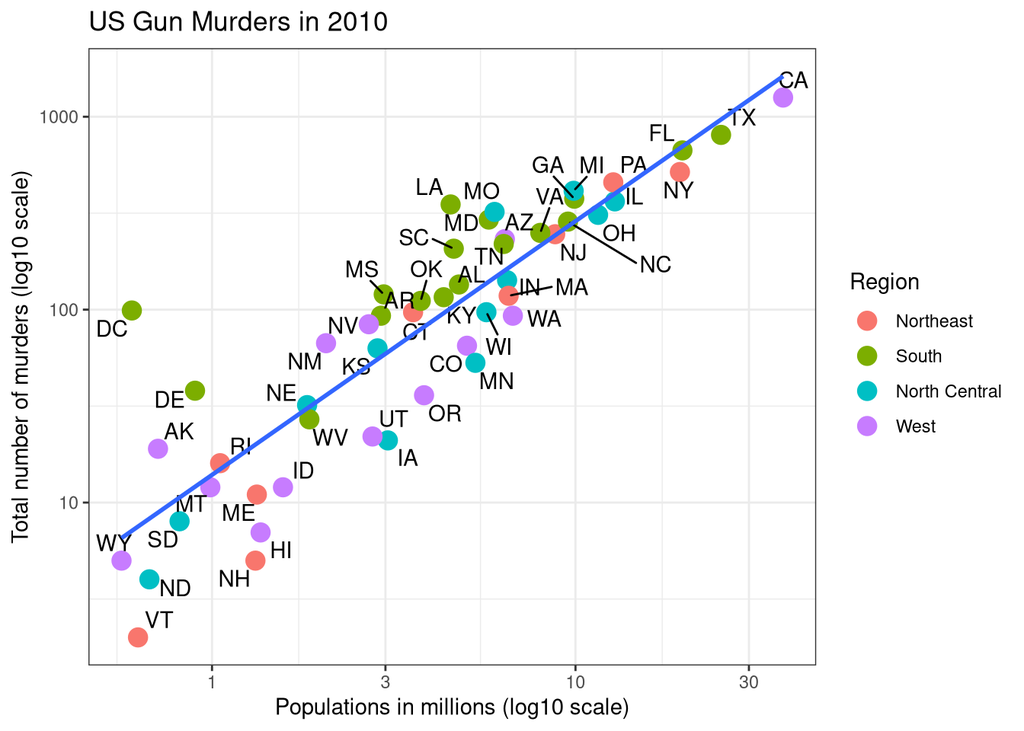

```r
ggplot1 = murders %>% ggplot(mapping = aes(x=population/10^6, y=total))

  ggplot1 + geom_point(aes(col=region), size = 4) +
  geom_text_repel(aes(label=abb)) +
  scale_x_log10() +
  scale_y_log10() +
  geom_smooth(formula = "y~x", method=lm,se = F)+
  xlab("Populations in millions (log10 scale)") +
  ylab("Total number of murders (log10 scale)") +
  ggtitle("US Gun Murders in 2010") +
  scale_color_discrete(name = "Region")+
      theme_bw()
```

## References

1. Zeger, S. L., Wu, Z., Coley, Y., Fojo, A. T., Carter, B., O’Brien, K., Zandi, P., Cooke, M., Carey, V., Crainiceanu, C., Muscelli, J., Gherman, A., & Mekosh, J. (2020). Using a Bayesian Approach to Predict Patients’ Health and Response to Treatment. https://doi.org/10.25302/09.2020.ME.140820318
2. Chatzimichail, T., & Hatjimihail, A. T. (2023). A Bayesian Inference Based Computational Tool for Parametric and Nonparametric Medical Diagnosis. Diagnostics, 13(19). https://doi.org/10.3390/DIAGNOSTICS13193135
3. van de Schoot, R., Depaoli, S., King, R., Kramer, B., Märtens, K., Tadesse, M. G., Vannucci, M., Gelman, A., Veen, D., Willemsen, J., & Yau, C. (2021). Bayesian statistics and modelling. Nature Reviews Methods Primers, 1(1), 1–26. https://doi.org/10.1038/S43586-020-00001-2;SUBJMETA=531,639,648,705,706;KWRD=SCIENTIFIC+COMMUNITY,STATISTICS
4. Klauenberg, K., Wübbeler, G., Mickan, B., Harris, P., & Elster, C. (2015). A tutorial on Bayesian Normal linear regression. Metrologia, 52(6), 878–892. https://doi.org/10.1088/0026-1394/52/6/878
5. de Leeuw, C., & Klugkist, I. (2012). Augmenting Data With Published Results in Bayesian Linear Regression. Multivariate Behavioral Research, 47(3), 369–391. https://doi.org/10.1080/00273171.2012.673957
6. Liu YM, Chen SLS, Yen AMF, Chen HH. Individual risk prediction model for incident cardiovascular disease: A Bayesian clinical reasoning approach. International Journal of Cardiology [Internet]. 2013 Sep 1 [cited 2025 Aug 28];167(5):2008–12. Available from: https://pubmed.ncbi.nlm.nih.gov/22658349/

## References

R Core Team. 2019. *R: A Language and Environment for Statistical Computing*. Vienna, Austria: R Foundation for Statistical Computing. https://www.R-project.org.